# Project: The Movie Database (TMDb) Project

- Introduction
- Data Wrangling
- Exploratory Data Analysis
- Conclusions

## Introduction

The data set of "Tmdb-movies" contains statistics about films from 1960 to 2015, their ratings, and some information such as production year, revenue, budget, actors, etc. We'll show the data and discovering quality and tightness issues then we clean that data and answer the mentioned questions.

- which genre have the highest revenue ?
- which lead actor have the highest revenue ?
- Does rating affects revenue ?
- What year was the largest number of films produced?
- What is the highest-grossing movie annually?
- which director have the highest revenues ?
- Does runtime affects revenues ?
- Does increasing the budget corresponds to increased rating and revenue or not ?
- What are the statistics on movie revenues in the year 2010?
- What year did the budget reach its peak, and in which year was the highest revenue obtained?

# Importing libraries

```python
import pandas as pd
import numpy as np
import matplotlib.pyplot as plt
import seaborn
%matplotlib inline
```

# Data Wrangling

### General Properties

#### Gathering Data

```python
# GATHER DATA FROM tmdb-movies
df_movie = pd.read_csv("tmdb-movies.csv")
```

#### View data

```python
df_movie.head()
```

|  | id | imdb_id | popularity | budget | revenue | original_title | cast | homepage | director | tagline | ... | overview | runtime | genres | production_companies | release_date | vote_count | vote_average | release_year | budget_adj | revenue_adj |
| --- | --- | --- | --- | --- | --- | --- | --- | --- | --- | --- | --- | --- | --- | --- | --- | --- | --- | --- | --- | --- | --- |
| 0 | 135397 | tt0369610 | 32.985763 | 150000000 | 1513528810 | Jurassic World | Chris Pratt\|Bryce Dallas Howard\|Irrfan Khan\|Vi... | http://www.jurassicworld.com/ | Colin Trevorrow | The park is open. | ... | Twenty-two years after the events of Jurassic ... | 124 | Action\|Adventure\|Science Fiction\|Thriller | Universal Studios\|Amblin Entertainment\|Legenda... | 6/9/15 | 5562 | 6.5 | 2015 | 1.379999e+08 | 1.392446e+09 |
| 1 | 76341 | tt1392190 | 28.419936 | 150000000 | 378436354 | Mad Max: Fury Road | Tom Hardy\|Charlize Theron\|Hugh Keays-Byrne\|Nic... | http://www.madmaxmovie.com/ | George Miller | What a Lovely Day. | ... | An apocalyptic story set in the furthest reach... | 120 | Action\|Adventure\|Science Fiction\|Thriller | Village Roadshow Pictures\|Kennedy Miller Produ... | 5/13/15 | 6185 | 7.1 | 2015 | 1.379999e+08 | 3.481613e+08 |
| 2 | 262500 | tt2908446 | 13.112507 | 110000000 | 295238201 | Insurgent | Shailene Woodley\|Theo James\|Kate Winslet\|Ansel... | http://www.thedivergentseries.movie/#insurgent | Robert Schwentke | One Choice Can Destroy You | ... | Beatrice Prior must confront her inner demons ... | 119 | Adventure\|Science Fiction\|Thriller | Summit Entertainment\|Mandeville Films\|Red Wago... | 3/18/15 | 2480 | 6.3 | 2015 | 1.012000e+08 | 2.716190e+08 |
| 3 | 140607 | tt2488496 | 11.173104 | 200000000 | 2068178225 | Star Wars: The Force Awakens | Harrison Ford\|Mark Hamill\|Carrie Fisher\|Adam D... | http://www.starwars.com/films/star-wars-episod... | J.J. Abrams | Every generation has a story. | ... | Thirty years after defeating the Galactic Empi... | 136 | Action\|Adventure\|Science Fiction\|Fantasy | Lucasfilm\|Truenorth Productions\|Bad Robot | 12/15/15 | 5292 | 7.5 | 2015 | 1.839999e+08 | 1.902723e+09 |
| 4 | 168259 | tt2820852 | 9.335014 | 190000000 | 1506249360 | Furious 7 | Vin Diesel\|Paul Walker\|Jason Statham\|Michelle ... | http://www.furious7.com/ | James Wan | Vengeance Hits Home | ... | Deckard Shaw seeks revenge against Dominic Tor... | 137 | Action\|Crime\|Thriller | Universal Pictures\|Original Film\|Media Rights ... | 4/1/15 | 2947 | 7.3 | 2015 | 1.747999e+08 | 1.385749e+09 |

5 rows × 21 columns

#### View information of data

```python
df_movie.info()
```

```
<class 'pandas.core.frame.DataFrame'>
RangeIndex: 10866 entries, 0 to 10865
Data columns (total 21 columns):
 #   Column                Non-Null Count  Dtype
---  ------                --------------  -----
 0   id                    10866 non-null  int64
 1   imdb_id               10856 non-null  object
 2   popularity            10866 non-null  float64
 3   budget                10866 non-null  int64
 4   revenue               10866 non-null  int64
 5   original_title        10866 non-null  object
 6   cast                  10790 non-null  object
 7   homepage              2936 non-null   object
 8   director              10822 non-null  object
 9   tagline               8042 non-null   object
 10  keywords              9373 non-null   object
 11  overview              10862 non-null  object
 12  runtime               10866 non-null  int64
 13  genres                10843 non-null  object
 14  production_companies  9836 non-null   object
 15  release_date          10866 non-null  object
 16  vote_count            10866 non-null  int64
 17  vote_average          10866 non-null  float64
 18  release_year          10866 non-null  int64
 19  budget_adj            10866 non-null  float64
 20  revenue_adj           10866 non-null  float64
dtypes: float64(4), int64(6), object(11)
memory usage: 1.7+ MB
```

#### View missing data

```python
df_movie.isnull().sum()
```

```
id                         0
imdb_id                   10
popularity                 0
budget                     0
revenue                    0
original_title             0
cast                      76
homepage                7930
director                  44
tagline                 2824
keywords                1493
overview                   4
runtime                    0
genres                    23
production_companies    1030
release_date               0
vote_count                 0
vote_average               0
release_year               0
budget_adj                 0
revenue_adj                0
dtype: int64
```

#### View duplicated data

```python
sum(df_movie.duplicated())
```

```
1
```

## Assess Data

### QUALTIY DIMENSIONS

- completeness
  - missing values in (cast, director , imdb_id, genres)
- validity
  - id is a integer not a string
  - release_year is a integer not a string
- Data types(consistency issues):
  - ( runtime ) convert values ( 0 ) to ( mean of runtime )
- accurancy
  - ( df_movie ) Erroneous datatype ( release_date )

### Tidiness

- Drop column ( homepage,tagline, keywords, production_companies )
- Drop duplicate row
- Drop row that revenue = 0 and budget = 0

## Cleaning Of Data

```python
#Copy of Data
df_movie_clean = df_movie.copy()
```

Define

##### Drop duplicate row

code

```python
df_movie_clean.drop_duplicates(inplace=True)
```

test

```python
sum(df_movie_clean.duplicated())
```

```
0
```

Define

##### Drop column ( homepage ,tagline, keywords ,production_companies )

Code

```python
df_movie_clean.drop(columns=['homepage','tagline','keywords','production_companies'], axis=1, inplace=True)
```

Test

```python
df_movie_clean.info()
```

```
<class 'pandas.core.frame.DataFrame'>
Int64Index: 10865 entries, 0 to 10865
Data columns (total 17 columns):
 #   Column          Non-Null Count  Dtype
---  ------          --------------  -----
 0   id              10865 non-null  int64
 1   imdb_id         10855 non-null  object
 2   popularity      10865 non-null  float64
 3   budget          10865 non-null  int64
 4   revenue         10865 non-null  int64
 5   original_title  10865 non-null  object
 6   cast            10789 non-null  object
 7   director        10821 non-null  object
 8   overview        10861 non-null  object
 9   runtime         10865 non-null  int64
 10  genres          10842 non-null  object
 11  release_date    10865 non-null  object
 12  vote_count      10865 non-null  int64
 13  vote_average    10865 non-null  float64
 14  release_year    10865 non-null  int64
 15  budget_adj      10865 non-null  float64
 16  revenue_adj     10865 non-null  float64
dtypes: float64(4), int64(6), object(7)
memory usage: 1.5+ MB
```

Define

#### Drop row that revenue = 0 and budget = 0

Code

```python
df_movie_clean= df_movie_clean[~((df_movie_clean['budget'] == 0) & (df_movie_clean['revenue']==0))]
```

Test

```python
df_budget = df_movie_clean[df_movie_clean['budget']==0]
df_revenue = df_movie_clean[df_movie_clean['revenue']==0]
print("the budget is : "+str(len(df_budget)) + " and revenue " +str(len(df_revenue)))
```

```
the budget is : 995 and revenue 1315
```

Define

#### Convert id and release_year column from integer to string

Code

```python
df_movie_clean['id'] = df_movie_clean['id'].astype(str)
df_movie_clean['release_year'] = df_movie_clean['release_year'].astype(str)
```

Test

```python
df_movie_clean.info()
```

```
<class 'pandas.core.frame.DataFrame'>
Int64Index: 6164 entries, 0 to 10865
Data columns (total 17 columns):
 #   Column          Non-Null Count  Dtype
---  ------          --------------  -----
 0   id              6164 non-null   object
 1   imdb_id         6163 non-null   object
 2   popularity      6164 non-null   float64
 3   budget          6164 non-null   int64
 4   revenue         6164 non-null   int64
 5   original_title  6164 non-null   object
 6   cast            6152 non-null   object
 7   director        6160 non-null   object
 8   overview        6164 non-null   object
 9   runtime         6164 non-null   int64
 10  genres          6163 non-null   object
 11  release_date    6164 non-null   object
 12  vote_count      6164 non-null   int64
 13  vote_average    6164 non-null   float64
 14  release_year    6164 non-null   object
 15  budget_adj      6164 non-null   float64
 16  revenue_adj     6164 non-null   float64
dtypes: float64(4), int64(4), object(9)
memory usage: 866.8+ KB
```

Define

#### Convert release_date column to datatime

Code

```python
df_movie_clean['release_date'] = df_movie_clean['release_date'].astype('datetime64[ns]')
```

Test

```python
df_movie_clean.info()
```

```
<class 'pandas.core.frame.DataFrame'>
Int64Index: 6164 entries, 0 to 10865
Data columns (total 17 columns):
 #   Column          Non-Null Count  Dtype
---  ------          --------------  -----
 0   id              6164 non-null   object
 1   imdb_id         6163 non-null   object
 2   popularity      6164 non-null   float64
 3   budget          6164 non-null   int64
 4   revenue         6164 non-null   int64
 5   original_title  6164 non-null   object
 6   cast            6152 non-null   object
 7   director        6160 non-null   object
 8   overview        6164 non-null   object
 9   runtime         6164 non-null   int64
 10  genres          6163 non-null   object
 11  release_date    6164 non-null   datetime64[ns]
 12  vote_count      6164 non-null   int64
 13  vote_average    6164 non-null   float64
 14  release_year    6164 non-null   object
 15  budget_adj      6164 non-null   float64
 16  revenue_adj     6164 non-null   float64
dtypes: datetime64[ns](1), float64(4), int64(4), object(8)
memory usage: 866.8+ KB
```

Define

#### Fixing columns that contain of nan values

[output not shown]

Code

```python
df_movie_clean['cast'].fillna('No cast',inplace = True)
df_movie_clean['director'].fillna('No director',inplace = True)
df_movie_clean['imdb_id'].fillna('No imdb_id',inplace = True)
df_movie_clean['overview'].fillna('No overview',inplace = True)
df_movie_clean['genres'].fillna('No genres',inplace = True)
df_movie_clean['runtime'] = df_movie_clean['runtime'].replace(0, df_movie_clean['runtime'].mean())
```

Test

To show missing values in data set

```python
df_movie_clean.isnull().sum()
```

```
id                0
imdb_id           0
popularity        0
budget            0
revenue           0
original_title    0
cast              0
director          0
overview          0
runtime           0
genres            0
release_date      0
vote_count        0
vote_average      0
release_year      0
budget_adj        0
revenue_adj       0
dtype: int64
```

```python
df_movie_clean.info()
```

```
<class 'pandas.core.frame.DataFrame'>
Int64Index: 6164 entries, 0 to 10865
Data columns (total 17 columns):
 #   Column          Non-Null Count  Dtype
---  ------          --------------  -----
 0   id              6164 non-null   object
 1   imdb_id         6164 non-null   object
 2   popularity      6164 non-null   float64
 3   budget          6164 non-null   int64
 4   revenue         6164 non-null   int64
 5   original_title  6164 non-null   object
 6   cast            6164 non-null   object
 7   director        6164 non-null   object
 8   overview        6164 non-null   object
 9   runtime         6164 non-null   float64
 10  genres          6164 non-null   object
 11  release_date    6164 non-null   datetime64[ns]
 12  vote_count      6164 non-null   int64
 13  vote_average    6164 non-null   float64
 14  release_year    6164 non-null   object
 15  budget_adj      6164 non-null   float64
 16  revenue_adj     6164 non-null   float64
dtypes: datetime64[ns](1), float64(5), int64(3), object(8)
memory usage: 866.8+ KB
```

## Store Of Dataset Movie_master

```python
df_movie_clean.to_csv('Movie_master', index = False)
```

## Exploratory Data Analysis

### Question 1 : which genre have the highest revenue ?

we will create a list of the genre to find the total revenue for each genre

```python
list_genre =df_movie_clean['genres']  #list of genre
dict_revenue_genre = {}
for genre in list_genre:
    revenue_genre = df_movie_clean[df_movie_clean['genres'] == genre]['revenue'].sum()
    dict_revenue_genre[genre]=revenue_genre
```

```python
# to extract genre by using high revenue
high_revenue = max(dict_revenue_genre.values())
genre = ''
for genres , revenue in dict_revenue_genre.items():
    if high_revenue== revenue:
        genre = genres
        break

genre , high_revenue
```

```
('Comedy', 20323889661)
```

#### Visual between genre and revenues

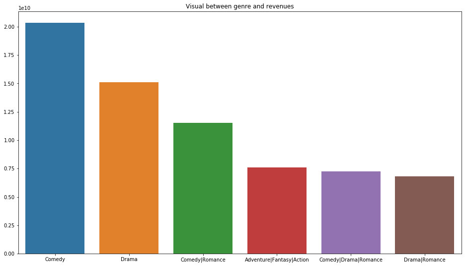

```python
fig, ax =  plt.subplots(figsize =(16, 9))
ax.set_title('Visual between genre and revenues')
dict_revenue_genre = dict(sorted(dict_revenue_genre.items(), key=lambda item: item[1],reverse=True))
dict_seaborn ={}
i = 0
for genre , revenue in dict_revenue_genre.items():
    dict_seaborn[genre] =revenue
    i+=1
    if i ==6:
        break
seaborn.barplot(x=list(dict_seaborn.keys()),y=list(dict_seaborn.values()))
plt.show()
```

#### Visual between genre and revenues by using pie plot

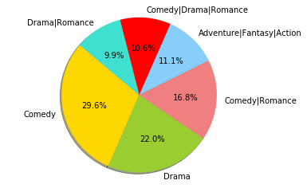

```python
labels = dict_seaborn.keys()
sizes = dict_seaborn.values()
colors = ['gold', 'yellowgreen', 'lightcoral', 'lightskyblue','red','turquoise','redyellow']
plt.pie(sizes, labels=labels, colors=colors,
autopct='%1.1f%%', shadow=True, startangle=140)
plt.axis('equal')
plt.show()
```

```python
print("Answer :It becomes clear to us that the genre owner of the highest revenues is "+list(dict_revenue_genre.keys())[0]+" which amounts to his revenues {} .".format(list(dict_revenue_genre.values())[0]))
```

```
Answer :It becomes clear to us that the genre owner of the highest revenues is Comedy which amounts to his revenues 20323889661 .
```

### Question 2 : What is the highest-grossing movie annually?

We will create a list of unique years to find the max of revenue for each year

```python
list_years = df_movie_clean['release_year'].unique() # list of unique years
dict_yr_mov = {}
for year in list_years:
        high_revenue = max(df_movie_clean[df_movie_clean['release_year'] == year]['revenue'])
        title = df_movie_clean[(df_movie_clean['release_year'] == year) & (df_movie_clean['revenue'] == high_revenue)]['original_title'].to_string(index=False)
        dict_yr_mov[year] = title
```

```python
print("Answer :We can notice that the highest film in the year 2015 was:"+ dict_yr_mov['2015']+" and 2014 was:"+dict_yr_mov['2014']+" and 2013 was:"+dict_yr_mov['2013']
+"and we can know the rest of the films that have received the highest revenues since the year 1960.")
```

```
Answer :We can notice that the highest film in the year 2015 was: Star Wars: The Force Awakens and 2014 was: The Hobbit: The Battle of the Five Armies and 2013 was: Frozenand we can know the rest of the films that have received the highest revenues since the year 1960.
```

### Question 3 : Does runtime affects revenues ?

we will create a list of unique runtime to find the total of revenue for each runtime

```python
list_runtime = df_movie_clean['runtime'].unique() # list of unique years
dict_run_revenue = {}
for runtime in list_runtime:
        sum_revenue = df_movie_clean[df_movie_clean['runtime'] == runtime]['revenue'].sum()
        dict_run_revenue[runtime] = sum_revenue
```

#### Visual between runtime and revenues

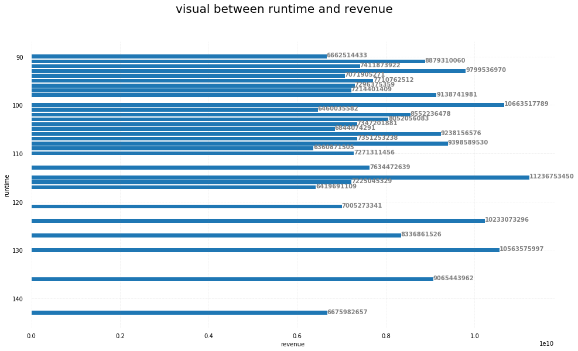

```python
dict_run_revenue = dict(sorted(dict_run_revenue.items(), key=lambda item: item[1],reverse=True))
#We will only use the first 30 items from the dictionary to use in visuales
dict_seaborn ={}
i = 0
for genre , revenue in dict_run_revenue.items():
    dict_seaborn[genre] =revenue
    i+=1
    if i ==30:
        break

runtime = list(dict_seaborn.keys())
revenue = list(dict_seaborn.values())

fig, ax = plt.subplots(figsize =(16, 9))
ax.barh(runtime, revenue)

for s in ['top', 'bottom', 'left', 'right']:
    ax.spines[s].set_visible(False)
ax.xaxis.set_ticks_position('none')
ax.yaxis.set_ticks_position('none')

ax.xaxis.set_tick_params(pad = 5)
ax.yaxis.set_tick_params(pad = 10)

ax.grid(b = True, color ='grey',
        linestyle ='-.', linewidth = 0.5,
        alpha = 0.2)

ax.invert_yaxis()

for i in ax.patches:
    plt.text(i.get_width()+0.2, i.get_y()+0.5,
             str(round((i.get_width()), 2)),
             fontsize = 10, fontweight ='bold',
             color ='grey')
plt.xlabel('revenue')
plt.ylabel('runtime')
fig.suptitle('visual between runtime and revenue', fontsize=20)
# Show Plot
plt.show()
```

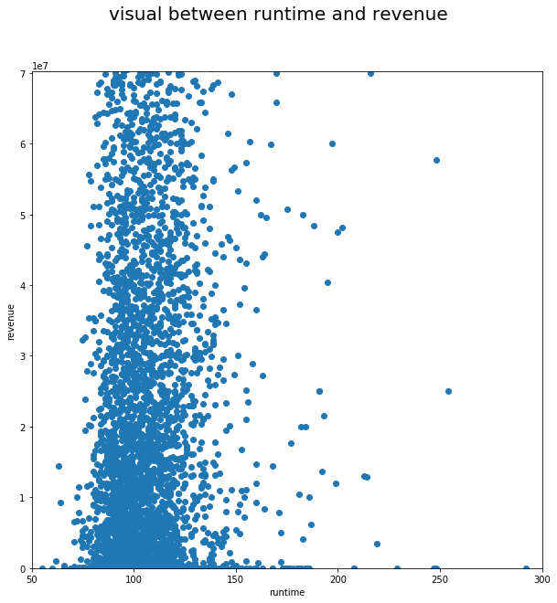

```
0.21735116223573014
```

```python
fig = plt.figure(figsize=(10, 10))
fig.suptitle('visual between runtime and revenue', fontsize=20)
plt.scatter(df_movie_clean['runtime'],df_movie_clean['revenue'])
plt.xlabel('runtime')
plt.ylabel('revenue')
plt.xlim([50, 300])
plt.ylim([0, df_movie_clean['revenue'].mean()])
plt.show()
df_movie_clean['runtime'].corr(df_movie_clean['revenue'])
```

```python
print("Answer :It is clear from the chart that there is a relationship, but not enough, so we note that films with a duration of less than 150 minutes and more than 80 minutes get more revenues than films that fall outside this range.")
```

```
Answer :It is clear from the chart that there is a relationship, but not enough, so we note that films with a duration of less than 150 minutes and more than 80 minutes get more revenues than films that fall outside this range.
```

### Question 4 : which director have the highest revenues ?

we will create a list of unique director to find the total of revenue for each director

```python
list_director = df_movie_clean['director'].unique() # list of unique directors
dict_director_revenue = {}
for director in list_director:
        sum_revenue = df_movie_clean[df_movie_clean['director'] == director]['revenue'].sum()
        dict_director_revenue[director] = sum_revenue

dict_director_revenue = dict(sorted(dict_director_revenue.items(), key=lambda item: item[1],reverse=True))
```

#### Visual between director and revenues

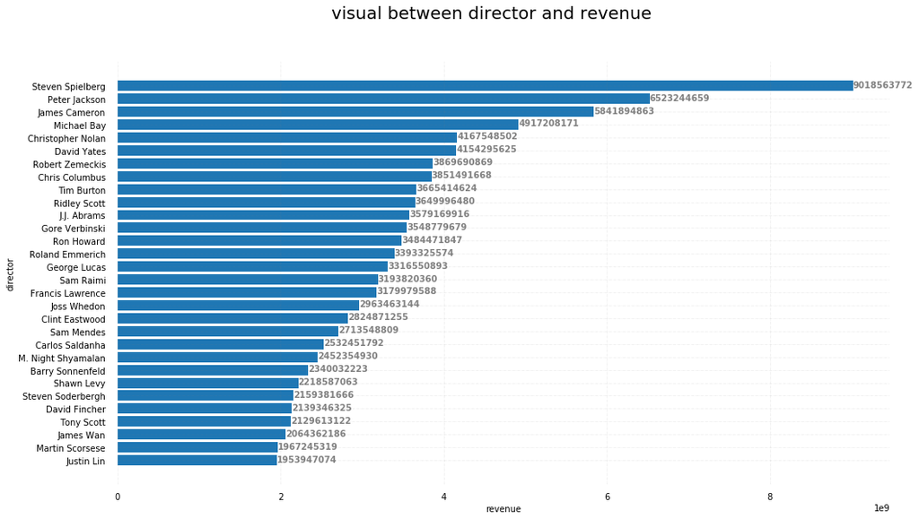

```python
#We will only use the first 30 items from the dictionary to use in visuales
dict_seaborn ={}
i = 0
for director , revenue in dict_director_revenue.items():
    dict_seaborn[director] =revenue
    i+=1
    if i ==30:
        break

director = list(dict_seaborn.keys())
revenue = list(dict_seaborn.values())

fig, ax = plt.subplots(figsize =(16, 9))
ax.barh(director, revenue)

for s in ['top', 'bottom', 'left', 'right']:
    ax.spines[s].set_visible(False)
ax.xaxis.set_ticks_position('none')
ax.yaxis.set_ticks_position('none')

ax.xaxis.set_tick_params(pad = 5)
ax.yaxis.set_tick_params(pad = 10)

ax.grid(b = True, color ='grey',
        linestyle ='-.', linewidth = 0.5,
        alpha = 0.2)

ax.invert_yaxis()

for i in ax.patches:
    plt.text(i.get_width()+0.2, i.get_y()+0.5,
             str(round((i.get_width()), 2)),
             fontsize = 10, fontweight ='bold',
             color ='grey')
plt.xlabel('revenue')
plt.ylabel('director')
fig.suptitle('visual between director and revenue', fontsize=20)
# Show Plot
plt.show()
```

```python
print("Answer :Through the barplot, we can notice that the director with the highest revenues is "+list(dict_director_revenue.keys())[0]+".")
```

```
Answer :Through the barplot, we can notice that the director with the highest revenues is Steven Spielberg.
```

### Question 5 : Does rating affects revenue ?

we will create a list of unique vote_average to find the total of revenue for each vote_average

```python
list_rating = df_movie_clean['vote_average'].unique() # list of unique vote_averages
dict_rating_revenue = {}
for rating in list_rating:
        sum_revenue = df_movie_clean[df_movie_clean['vote_average'] == rating]['revenue'].sum()
        dict_rating_revenue[rating] = sum_revenue
```

#### Visual between rating and revenues

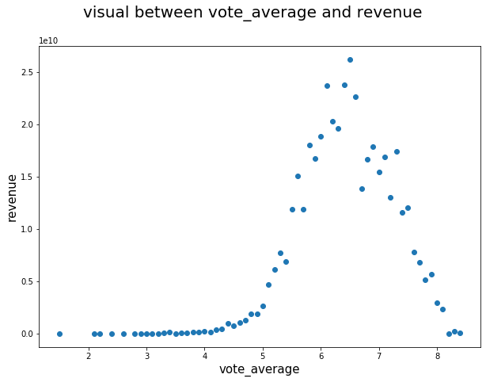

```python
fig = plt.figure(figsize=(10, 7))
plt.scatter(dict_rating_revenue.keys(),dict_rating_revenue.values())
plt.xlabel('vote_average', fontsize=15)
plt.ylabel('revenue', fontsize=15)
fig.suptitle('visual between vote_average and revenue', fontsize=20)
plt.show()
```

```python
print("Answer :It is evident from the chart that we cannot have an explicit relationship between revenues and the average rating, as we notice that the revenue after 5 average_rating is increasing, then after passing 7 average_rating, it begins to decline, and this indicates that there is no relationship between them.")
```

[output not shown]

### Question 6 : which lead actor have the highest revenue ?

```python
list_lead_actor = df_movie_clean['cast'].unique() # list of unique vote_averages
lst_lead_actor = []
# we will split cast string to extract first name from this and store into lst_lead_actor
for lead_actor in list_lead_actor:
    lead_actor = lead_actor.split('|')[0]
    lst_lead_actor.append(lead_actor)
lst_lead_actor

dict_actor_revenue = {}
for lead_actor in lst_lead_actor:
        sum_revenue = df_movie_clean[df_movie_clean['cast'].str.contains(lead_actor)]['revenue'].sum()
        dict_actor_revenue[lead_actor] = sum_revenue

dict_actor_revenue = dict(sorted(dict_actor_revenue.items(), key=lambda item: item[1],reverse=True))
```

#### Visual between lead actor and revenues

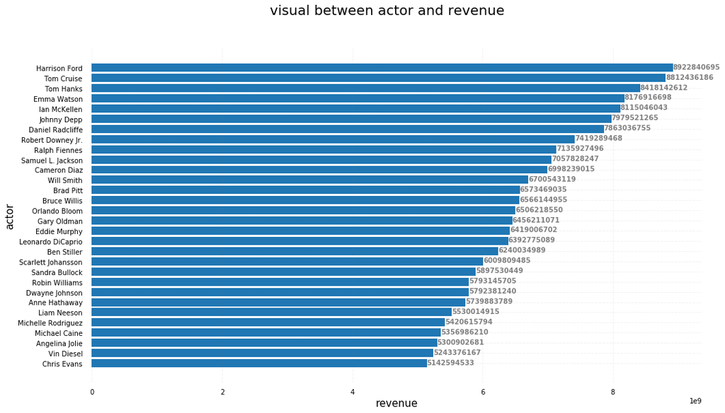

```python
dict_seaborn ={}
i = 0
for actor , revenue in dict_actor_revenue.items():
    dict_seaborn[actor] =revenue
    i+=1
    if i ==30:
        break

actor = list(dict_seaborn.keys())
revenue = list(dict_seaborn.values())

fig, ax = plt.subplots(figsize =(16, 9))
ax.barh(actor, revenue)

for s in ['top', 'bottom', 'left', 'right']:
    ax.spines[s].set_visible(False)
ax.xaxis.set_ticks_position('none')
ax.yaxis.set_ticks_position('none')

ax.xaxis.set_tick_params(pad = 5)
ax.yaxis.set_tick_params(pad = 10)

ax.grid(b = True, color ='grey',
        linestyle ='-.', linewidth = 0.5,
        alpha = 0.2)

ax.invert_yaxis()

for i in ax.patches:
    plt.text(i.get_width()+0.2, i.get_y()+0.5,
             str(round((i.get_width()), 2)),
             fontsize = 10, fontweight ='bold',
             color ='grey')
plt.xlabel('revenue', fontsize=15)
plt.ylabel('actor', fontsize=15)
fig.suptitle('visual between actor and revenue', fontsize=20)
# Show Plot
plt.show()
```

```python
print("Answer :Through the barplot, we can notice that the lead actor with the highest revenues is "+list(dict_actor_revenue.keys())[0]+".")
```

```
Answer :Through the barplot, we can notice that the lead actor with the highest revenues is Harrison Ford.
```

### Question 7 : What year was the largest number of films produced?

```python
# A dictionary containing the year and the number of times it repeats, as the number of repetitions indicates the number of
# films made in that year
dict_years = dict(df_movie_clean['release_year'].value_counts())
dict_years = dict(sorted(dict_years.items(), key=lambda item: item[1],reverse=False))
```

#### Visual between film_count and years

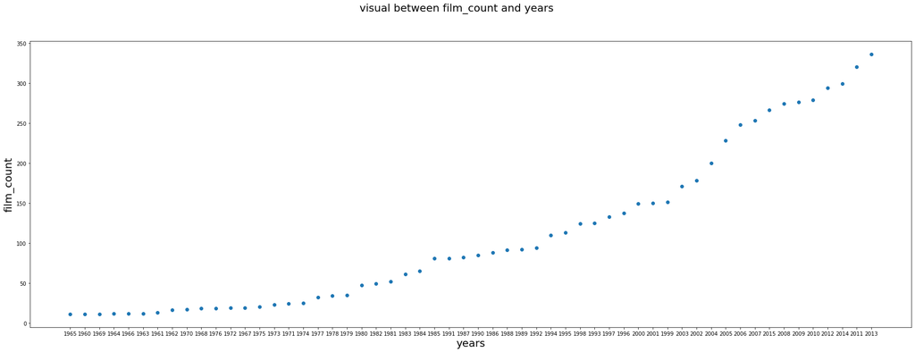

```python
fig = plt.figure(figsize=(30,10))
plt.scatter(dict_years.keys(),dict_years.values())
plt.xlabel('years', fontsize=20)
plt.ylabel('film_count', fontsize=20)
fig.suptitle('visual between film_count and years', fontsize=20)
plt.show()
```

```python
print("Answer :From the chart, we can notice that "+list(dict_years.keys())[-1]+" is the year in which the largest number of films were produced.")
```

```
Answer :From the chart, we can notice that 2013 is the year in which the largest number of films were produced.
```

### Question 8 : Does increasing the budget corresponds to increased rating and revenue or not ?

#### Visual between budget and vote_average

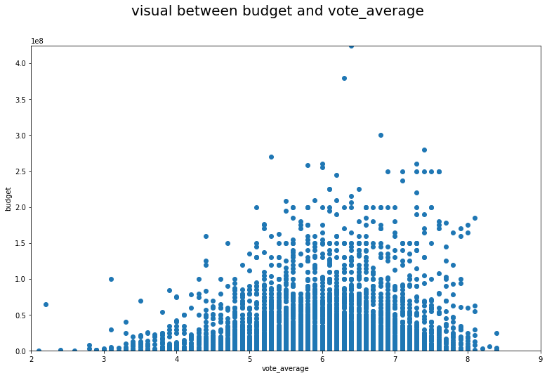

```
0.07595499456393713
```

```python
fig = plt.figure(figsize=(13, 8))
fig.suptitle('visual between budget and vote_average', fontsize=20)
plt.scatter(df_movie_clean['vote_average'],df_movie_clean['budget'])
plt.xlabel('vote_average')
plt.ylabel('budget')
plt.xlim([2, 9])
plt.ylim([0, df_movie_clean['budget'].max()])
plt.show()
df_movie_clean['vote_average'].corr(df_movie_clean['budget'])
```

```python
print("Answer :It is clear to us from the chart that we cannot get an explicit relationship between budget and avarage rating , and this indicates that there is no relationship between them.")
```

```
Answer :It is clear to us from the chart that we cannot get an explicit relationship between budget and avarage rating , and this indicates that there is no relationship between them.
```

#### Visual between budget and revenue

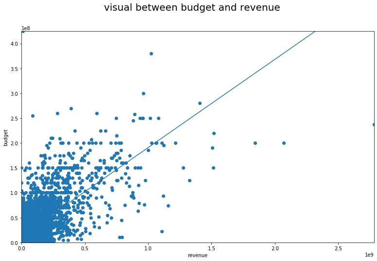

```
0.703985483086692
```

```python
fig = plt.figure(figsize=(13, 8))
fig.suptitle('visual between budget and revenue', fontsize=20)
plt.scatter(df_movie_clean['revenue'],df_movie_clean['budget'])
plt.xlabel('revenue')
plt.ylabel('budget')
plt.xlim([0, df_movie_clean['revenue'].max()])
plt.ylim([0, df_movie_clean['budget'].max()])
plt.plot(np.unique(df_movie_clean['revenue']),
         np.poly1d(np.polyfit(df_movie_clean['revenue'],
                              df_movie_clean['budget'],
                              1))(np.unique(df_movie_clean['revenue'])))
plt.show()
df_movie_clean['revenue'].corr(df_movie_clean['budget'])
```

```python
print("Answer :Through the chart, we can notice the existence of a correlation positive between revenue and budget = 0.7039854 .")
```

```
Answer :Through the chart, we can notice the existence of a correlation positive between revenue and budget = 0.7039854 .
```

```python
sum_revenue={}  #sum of revenue for each month
for month in df_movie_clean['release_date'].dt.month:
    sum_revenue[month]=np.sum(df_movie_clean[df_movie_clean['release_date'].dt.month==month]['revenue'])
```

```python
sum_revenue_list= list(sum_revenue.values())

val_list = list(sum_revenue.values())
key_list = list(sum_revenue.keys())
mean_value = np.mean(sum_revenue_list)
max_value = max(sum_revenue_list)
min_value = min(sum_revenue_list)
quartile_1 = np.percentile(sum_revenue_list, 25, interpolation="nearest")
quartile_3 = np.percentile(sum_revenue_list, 75, interpolation="nearest")
quartile_2 = np.percentile(sum_revenue_list, 50, interpolation="nearest")
```